# Sympton tracker Analysis

Last updated: 03/02/2022

A notebook which loads cleaned flat files of Zoe's Symptom Tracker database, does some light feature engineering, and then undertakes some applications such as trying to replicate the original logistic regression, and then some predictive work.

```
1. Load libraries and data
2. Feature engineering
3. In-sample GLMs:
    3.1 Stepwise logistic regression
    3.2 Menni et al set ('small set') logistic regression
    3.3 Full-set logistic regression
4. Predict the GLMs OSS with 5 folds
5. IMV
6. Seeds
```

## 1. Load libraries and data

Lets first load in our dependancies:

```python
import os
import pandas as pd
import numpy as np
from sklearn.metrics import roc_auc_score
import matplotlib.pyplot as plt
import statsmodels.discrete.discrete_model as sm
import stepwise_selector
from imv_functions import ll, get_w, minimize_me, get_ew
from preprocess import simple_preprocess
from insample import plot_and_print_OR
from prediction_v2 import predict_oos, print_results, predict_oos_compare
update_string = '2020-04-24'
```

Lets define the path of charlies data which is output from the naive 'convert_rds_to_csv.R' file.

```python
data_path = os.path.join(os.getcwd(), '..', '..', 'data','charlie', 'processed')
out_path = os.path.join(os.getcwd(), '..', '..', 'data', 'charlie', 'results', 'second_version', update_string)
if os.path.isdir(out_path) is False:
    os.mkdir(out_path)
if os.path.isdir(os.path.join(out_path, 'imv')) is False:
    os.mkdir(os.path.join(out_path, 'imv'))
if os.path.isdir(os.path.join(out_path, 'roc_auc')) is False:
    os.mkdir(os.path.join(out_path, 'roc_auc'))
```

Lets load in the full dataset:

```python
df = pd.read_csv(os.path.join(data_path, 'set_full.csv'), index_col=0)
```

What columns are in this dataframe that we can use for prediction?

```python
df.columns
```

```
Index(['ID_E', 'PATIENT_ID_E', 'UPDATED_AT.x', 'COUNTRY_CODE.x',
       'HEALTH_STATUS', 'FEVER', 'TEMPERATURE', 'TEMPERATURE_UNIT',
       'PERSISTENT_COUGH', 'SHORTNESS_OF_BREATH', 'DIARRHOEA', 'SKIPPED_MEALS',
       'LOCATION', 'TESTED_COVID_POSITIVE', 'ABDOMINAL_PAIN', 'CHEST_PAIN',
       'LOSS_OF_SMELL', 'HEADACHE', 'NAUSEA', 'SORE_THROAT', 'FATIGUE',
       'HOARSE_VOICE', 'DELIRIUM', 'num_qs', 'included', 'week_updated',
       'year', 'DAY_UPDATED', 'has_covid', 'UPDATED_AT.y', 'COUNTRY_CODE.y',
       'YEAR_OF_BIRTH', 'HEIGHT_CM', 'WEIGHT_KG', 'GENDER', 'BMI',
       'RACE_IS_UK_ASIAN', 'RACE_IS_UK_BLACK', 'RACE_IS_UK_CHINESE',
       'RACE_IS_UK_MIDDLE_EASTERN', 'RACE_IS_UK_WHITE', 'RACE_IS_US_ASIAN',
       'RACE_IS_US_BLACK', 'RACE_IS_US_WHITE', 'ZIPCODE', 'LSOA11CD',
       'OUTWARD_POSTCODE_REGION'],
      dtype='object')
```

```python
df['Simple_Result'] = np.where(df['has_covid'].str.contains('positive'), 1, 0)
```

How many rows do we have?

```python
print(len(df), len(df[df['Simple_Result']==1]))
```

```
435390 27973
```

Lets make a list of the columns that we'll need to not be N/A

```python
with open(r'support_lists/cols_needed.txt') as f:
    cols_needed = [line.rstrip('\n') for line in f]
cols_needed.append('UPDATED_AT.x')
df = df[cols_needed].dropna()
```

How many rows do we have now?

```python
print(len(df))
```

```
430651
```

## 2. Feature Engineering

Lets collapse this into a feature set that we can actually use for prediction out of sample:

First lets set an optional date threshold:

```python
df = df[df['UPDATED_AT.x']< update_string]
```

How many rows and cases do we have now?

```python
print(len(df), df['Simple_Result'].mean())
```

```
4527 0.307046609233488
```

```python
df = simple_preprocess(df)
```

How many rows do we have now?

```python
print(len(df))
```

```
4493
```

Lets now turn this into a workable dataframe for everything below, as close as possible with the paper.

```python
with open(r'support_lists/full_feature_set.txt') as f:
    full_feature_set = [line.rstrip('\n') for line in f]

df = df[full_feature_set]
```

How does this relate to Table 1 in Menni et al?

```python
pd.merge(df[df['y']==1].mean().rename('Has Covid'),
         df[df['y']==0].mean().rename('No Covid'),
         how='left', left_index=True, right_index=True)
```

|  | Has Covid | No Covid |
| --- | --- | --- |
| y | 1.000000 | 0.000000 |
| age | 41.623188 | 42.012528 |
| female | 0.721014 | 0.765821 |
| bmi | 26.968542 | 26.594397 |
| asmosia | 0.512319 | 0.150980 |
| cough | 0.560870 | 0.411821 |
| fatigue | 0.227536 | 0.140700 |
| skipped_meals | 0.351449 | 0.216190 |
| shortness_of_breath | 0.003623 | 0.008031 |
| fever | 0.386957 | 0.221972 |
| delirium | 0.150725 | 0.129136 |
| diarrhoea | 0.218116 | 0.174109 |
| hoarse | 0.288406 | 0.233216 |
| chest_pain | 0.400000 | 0.370704 |
| abdominal_pain | 0.199275 | 0.171860 |

## 3. In-sample GLMs:

### 3.1 Stepwise logistic regression

```python
bfit = stepwise_selector.BestSubsetSelectionOLS(fK=7)
bfit.fit(df[full_feature_set].drop('y', 1), df['y'])
```

```
BestSubsetSelectionOLS(fK=7)
```

```python
df[full_feature_set].drop('y', 1).iloc[:,bfit.best_model.model.exog_names[1:]].columns
```

```
Index(['female', 'asmosia', 'cough', 'fever', 'delirium', 'chest_pain',
       'abdominal_pain'],
      dtype='object')
```

### 3.2 Menni et al set ('small set') logistic regression

prediction_model = -1.32 - (0.01 x age) + (0.44 x sex) + (1.75 x loss of smell) + (0.31 x severe or significant cough) + (0.49 x severe fatigue) + (0.39 x skipped meals)

```python
with open(r'support_lists/small_feature_set.txt') as f:
    small_feature_set = [line.rstrip('\n') for line in f]
```

```
                     5%       95%  Odds Ratio
const          0.231780  0.420994    0.312375
age            0.989152  1.000750    0.994934
female         0.594621  0.814492    0.695926
asmosia        4.695037  6.354619    5.462158
cough          1.411171  1.865409    1.622471
fatigue        0.872947  1.283474    1.058492
skipped_meals  1.041240  1.451699    1.229458
```

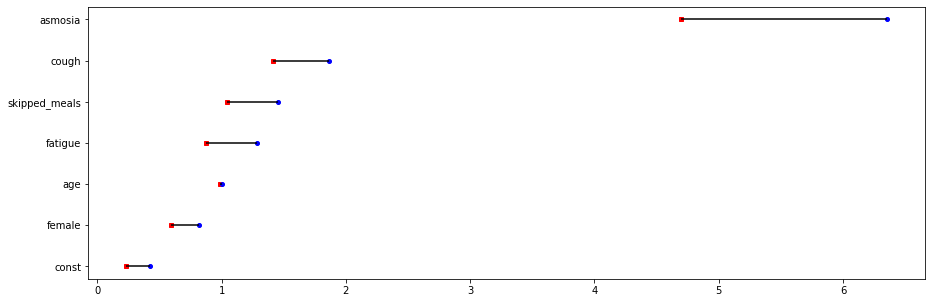

```python
regr = sm.Logit(df['y'], sm.tools.add_constant(df[small_feature_set].drop('y', 1))).fit(disp=0)
regr.summary()
plot_and_print_OR(regr)
```

### 3.3 Full-set logistic regression

```
                           5%       95%  Odds Ratio
const                0.162022  0.377857    0.247429
age                  0.989270  1.001166    0.995200
female               0.590377  0.813926    0.693198
bmi                  0.993785  1.018032    1.005835
asmosia              5.045130  6.894548    5.897787
cough                1.423388  1.907288    1.647668
fatigue              0.827400  1.254826    1.018942
skipped_meals        0.956544  1.362176    1.141482
shortness_of_breath  0.136006  1.139580    0.393688
fever                1.762446  2.430466    2.069678
delirium             0.582818  0.907880    0.727413
diarrhoea            0.830206  1.205521    1.000415
hoarse               0.864096  1.204656    1.020264
chest_pain           0.715774  0.974862    0.835333
abdominal_pain       0.660252  0.981674    0.805079
```

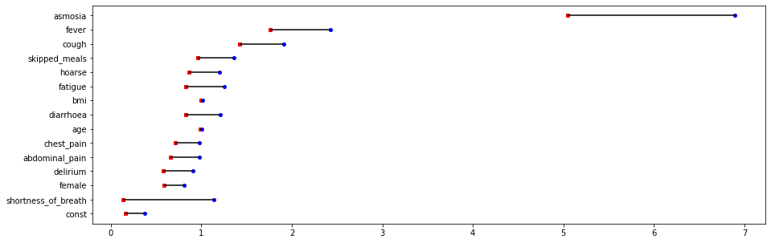

```python
regr = sm.Logit(df['y'], sm.tools.add_constant(df[full_feature_set].drop('y', 1))).fit(disp=0)
regr.summary()
plot_and_print_OR(regr)
```

## 4. Predict the GLMs OSS with 5 folds

```python
r2, roc_auc_full, imv_full = predict_oos(df[full_feature_set], 5, False, None)
print_results(roc_auc_full, imv_full)
```

```
AUC-ROC mean, min, max, sd: 0.7395038177758513 0.7106271238801359 0.7677150029616676 0.022486835952763427
IMV mean, min, max, sd: 0.11771907916954927 0.08140376099286928 0.16306419548961545 0.0279061828635426
```

```
S:\1150 - Covid-19 Symptom Tracker - Leverhulme Centre for Demographic Science\src\charlie\prediction_v2.py:44: FutureWarning: In a future version of pandas all arguments of DataFrame.drop except for the argument 'labels' will be keyword-only.
  X = sm.tools.add_constant(df.drop('y', 1))
```

```python
r2, roc_auc_small, imv_small = predict_oos(df[small_feature_set], 5, False, None)
print_results(roc_auc_small, imv_small)
```

```
S:\1150 - Covid-19 Symptom Tracker - Leverhulme Centre for Demographic Science\src\charlie\prediction_v2.py:44: FutureWarning: In a future version of pandas all arguments of DataFrame.drop except for the argument 'labels' will be keyword-only.
  X = sm.tools.add_constant(df.drop('y', 1))
```

```
AUC-ROC mean, min, max, sd: 0.7192356397686729 0.6927494593759653 0.7647561560375709 0.025951306195452058
IMV mean, min, max, sd: 0.10764079675489195 0.0729069965952889 0.1600043124346019 0.02902417029966308
```

```python
#roc_auc_full_select, imv_full_select = predict_oos(df[full_feature_set], 5, True, None)
#print_results(roc_auc_full_select, imv_full_select)
```

## 4.2 Predict the GLMs OSS with 10 folds

```python
r2, roc_auc_small, imv_small = predict_oos(df[small_feature_set], 10, False, None, False)
print_results(roc_auc_small, imv_small)
```

```
S:\1150 - Covid-19 Symptom Tracker - Leverhulme Centre for Demographic Science\src\charlie\prediction_v2.py:44: FutureWarning: In a future version of pandas all arguments of DataFrame.drop except for the argument 'labels' will be keyword-only.
  X = sm.tools.add_constant(df.drop('y', 1))
```

```
AUC-ROC mean, min, max, sd: 0.7210650010732295 0.683074079408517 0.7769647199155847 0.029761413733184
IMV mean, min, max, sd: 0.11028311263630966 0.06578195685552492 0.1708311564399679 0.03764591535048741
```

```python
r2, roc_auc_full, imv_full = predict_oos(df[full_feature_set], 10, False, None, False)
print_results(roc_auc_full, imv_full)
```

```
S:\1150 - Covid-19 Symptom Tracker - Leverhulme Centre for Demographic Science\src\charlie\prediction_v2.py:44: FutureWarning: In a future version of pandas all arguments of DataFrame.drop except for the argument 'labels' will be keyword-only.
  X = sm.tools.add_constant(df.drop('y', 1))
```

```
AUC-ROC mean, min, max, sd: 0.738587282130496 0.7027221662105718 0.7844657521677295 0.025721119195374106
IMV mean, min, max, sd: 0.11926044727291077 0.0729086458561941 0.162511239196546 0.03468685517210202
```

## 5. IMV

### 5.1.1 100 stratified draws, small feature set

```python
r2_small, roc_auc_small, imv_small = predict_oos(df[small_feature_set], 100, False, None, True)
file = 'imv_small_firstwave_100folds_noseeds_stratified'
pd.Series(imv_small, name='imv').to_csv(os.path.join(out_path, 'imv', file + '.csv'))
file = 'rocauc_small_firstwave_100folds_noseeds_stratified'
pd.Series(roc_auc_small, name='roc_auc').to_csv(os.path.join(out_path, 'roc_auc', file + '.csv'))
file = 'r2_small_firstwave_100folds_noseeds_stratified'
pd.Series(r2_small, name='r2').to_csv(os.path.join(out_path, 'r2', file + '.csv'))
print_results(roc_auc_small, imv_small)
```

```
S:\1150 - Covid-19 Symptom Tracker - Leverhulme Centre for Demographic Science\src\charlie\prediction_v2.py:44: FutureWarning: In a future version of pandas all arguments of DataFrame.drop except for the argument 'labels' will be keyword-only.
  X = sm.tools.add_constant(df.drop('y', 1))
```

```
AUC-ROC mean, min, max, sd: 0.7220008972881956 0.3605990783410138 0.9539170506912442 0.1060475949499015
IMV mean, min, max, sd: 0.09210490782130218 -0.2741436633547957 0.2689912442027438 0.09781781713763248
```

### 5.1.2 100 stratified draws, full feature set

```python
r2_full, roc_auc_full, imv_full = predict_oos(df[full_feature_set], 100, False, None, True)
file = 'imv_full_firstwave_100folds_noseeds_stratified'
pd.Series(imv_full, name='imv').to_csv(os.path.join(out_path, 'imv', file + '.csv'))
file = 'rocauc_full_firstwave_100folds_noseeds_stratified'
pd.Series(roc_auc_full, name='roc_auc').to_csv(os.path.join(out_path, 'roc_auc', file + '.csv'))
file = 'r2_full_firstwave_100folds_noseeds_stratified'
pd.Series(r2_small, name='r2').to_csv(os.path.join(out_path, 'r2', file + '.csv'))
print_results(roc_auc_full, imv_full)
```

```
S:\1150 - Covid-19 Symptom Tracker - Leverhulme Centre for Demographic Science\src\charlie\prediction_v2.py:44: FutureWarning: In a future version of pandas all arguments of DataFrame.drop except for the argument 'labels' will be keyword-only.
  X = sm.tools.add_constant(df.drop('y', 1))
```

```
AUC-ROC mean, min, max, sd: 0.7359211051045728 0.37327188940092165 0.9539170506912442 0.10649728173078024
IMV mean, min, max, sd: 0.10208958272720509 -0.2741436633547957 0.28389796507725473 0.09932819379868088
```

### 5.1.3 100 stratified draws, compared

```python
imv_compare = predict_oos_compare(df[small_feature_set], df[full_feature_set], 100, False, None, True)
file = 'imv_compared_firstwave_100folds_noseeds_stratified'
pd.Series(imv_compare, name='imv').to_csv(os.path.join(out_path, 'imv', file + '.csv'))
print("IMV mean, min, max, sd:", np.mean(imv_compare), np.min(imv_compare), np.max(imv_compare), np.std(imv_compare))
```

```
S:\1150 - Covid-19 Symptom Tracker - Leverhulme Centre for Demographic Science\src\charlie\prediction_v2.py:25: FutureWarning: In a future version of pandas all arguments of DataFrame.drop except for the argument 'labels' will be keyword-only.
  X1 = sm.tools.add_constant(df1.drop('y', 1))
S:\1150 - Covid-19 Symptom Tracker - Leverhulme Centre for Demographic Science\src\charlie\prediction_v2.py:27: FutureWarning: In a future version of pandas all arguments of DataFrame.drop except for the argument 'labels' will be keyword-only.
  X2 = sm.tools.add_constant(df2.drop('y', 1))
```

```
IMV mean, min, max, sd: 0.010389064986713832 -0.1730240859667535 0.27519527626079515 0.05236214999311895
```

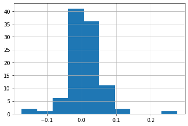

```python
pd.Series(imv_compare).hist()
```

## 6. Seeds

### 6.1.1 10K seeds five folds small feature set (unstratified)

```python
r2, roc_auc_small, imv_small = predict_oos(df[small_feature_set], 5, False, [*range(0,10000, 1)], False)
file = 'imv_small_firstwave_5folds_10kseeds_unstratified'
pd.Series(imv_small, name='imv').to_csv(os.path.join(out_path, 'imv', file + '.csv'))
file = 'roc_auc_small_firstwave_5folds_10kseeds_unstratified'
pd.Series(roc_auc_small, name='roc_auc').to_csv(os.path.join(out_path, 'roc_auc', file + '.csv'))

file = 'r2_small_firstwave_5folds_10kseeds_unstratified'
pd.Series(roc_auc_small, name='r2').to_csv(os.path.join(out_path, 'r2', file + '.csv'))

print_results(roc_auc_small, imv_small, 1)
```

```
S:\1150 - Covid-19 Symptom Tracker - Leverhulme Centre for Demographic Science\src\charlie\prediction_v2.py:44: FutureWarning: In a future version of pandas all arguments of DataFrame.drop except for the argument 'labels' will be keyword-only.
  X = sm.tools.add_constant(df.drop('y', 1))
```

```
AUC-ROC mean, min, max, sd: [0.72321398 0.72259402 0.72256748 ... 0.72498678 0.72385096 0.72373153] [0.70073863 0.702134   0.70950655 ... 0.7191282  0.70403529 0.67626899] [0.7383395  0.75589947 0.74070369 ... 0.73850194 0.74698525 0.74380826] [0.01331471 0.02033344 0.0104352  ... 0.00705352 0.01750…
IMV mean, min, max, sd: [0.11046433 0.11325414 0.11105846 ... 0.11129394 0.11458304 0.11068935] [0.08169661 0.07495935 0.0873482  ... 0.08959434 0.09072461 0.05757875] [0.13250318 0.15127576 0.13604265 ... 0.14171124 0.17971923 0.15273288] [0.01951442 0.03044977 0.01818862 ... 0.01859537 0.03344784 …
```

### 6.1.2 10K seeds five folds full feature set (unstratified)

```python
r2_full, roc_auc_full, imv_full = predict_oos(df[full_feature_set], 5, False, [*range(0,10000, 1)], False)
file = 'imv_full_firstwave_5folds_10kseeds_unstratified'
pd.Series(imv_full, name='imv').to_csv(os.path.join(out_path, 'imv', file + '.csv'))
file = 'roc_auc_full_firstwave_5folds_10kseeds_unstratified'
pd.Series(roc_auc_full, name='roc_auc').to_csv(os.path.join(out_path, 'roc_auc', file + '.csv'))
file = 'r2_full_firstwave_5folds_10kseeds_unstratified'
pd.Series(r2_full, name='r2').to_csv(os.path.join(out_path, 'r2', file + '.csv'))
print_results(roc_auc_full, imv_full, 1)
```

```
S:\1150 - Covid-19 Symptom Tracker - Leverhulme Centre for Demographic Science\src\charlie\prediction_v2.py:44: FutureWarning: In a future version of pandas all arguments of DataFrame.drop except for the argument 'labels' will be keyword-only.
  X = sm.tools.add_constant(df.drop('y', 1))
```

[output not shown]

```
AUC-ROC mean, min, max, sd: [0.74288719 0.74101413 0.74279669 ... 0.74503813 0.74418885 0.74220773] [0.71927887 0.70791873 0.72150504 ... 0.73200584 0.73212385 0.70200145] [0.7624104  0.77631797 0.76021832 ... 0.75933669 0.76163184 0.75688063] [0.01757594 0.02277311 0.0130127  ... 0.00972327 0.01029…
IMV mean, min, max, sd: [0.12185408 0.12381383 0.12145514 ... 0.12248998 0.12645147 0.12168775] [0.08699876 0.07458472 0.09759804 ... 0.10345737 0.10285787 0.06943077] [0.14721587 0.16576373 0.14240707 ... 0.15667577 0.18690166 0.16104763] [0.02209273 0.03485885 0.01825268 ... 0.0202336  0.03135036 …
```

### 6.1.3 10K seeds five folds small feature set (stratified)

```python
r2_small, roc_auc_small, imv_small = predict_oos(df[small_feature_set], 5, False, [*range(0,10000, 1)], True)
file = 'imv_small_firstwave_5folds_10kseeds_stratified'
pd.Series(imv_small, name='imv').to_csv(os.path.join(out_path, 'imv', file + '.csv'))
file = 'roc_auc_small_firstwave_5folds_10kseeds_stratified'
pd.Series(roc_auc_small, name='roc_auc').to_csv(os.path.join(out_path, 'roc_auc', file + '.csv'))
file = 'r2_small_firstwave_5folds_10kseeds_stratified'
pd.Series(r2_small, name='r2').to_csv(os.path.join(out_path, 'r2', file + '.csv'))
print_results(roc_auc_small, imv_small, 1)
```

```
S:\1150 - Covid-19 Symptom Tracker - Leverhulme Centre for Demographic Science\src\charlie\prediction_v2.py:44: FutureWarning: In a future version of pandas all arguments of DataFrame.drop except for the argument 'labels' will be keyword-only.
  X = sm.tools.add_constant(df.drop('y', 1))
```

```
AUC-ROC mean, min, max, sd: [0.72319649 0.72360807 0.72402077 ... 0.72356798 0.72304619 0.72332311] [0.69946437 0.69243383 0.71321272 ... 0.71213127 0.71208176 0.69243609] [0.74533289 0.75131144 0.73807488 ... 0.73112389 0.73678089 0.75663183] [0.017633   0.02122077 0.01027612 ... 0.00669598 0.00927…
IMV mean, min, max, sd: [0.10822524 0.10843121 0.10922437 ... 0.10888858 0.10846903 0.10768313] [0.07456556 0.08615641 0.09214676 ... 0.1031522  0.09691847 0.08694733] [0.12574889 0.12619304 0.12094564 ... 0.11592393 0.11750401 0.13285206] [0.01789679 0.01353137 0.01147965 ... 0.00447544 0.00661151 …
```